# R Notebook

Se cargan los datos y las librerias

```r
library(tidyverse)
```

```
library(tidyverse)
```

[output not shown]

```r
library(tidyverse)
library(ggpubr)
```

```r
library(ggpubr)
load('../Pre-procesamiento/dataset_final.rda')
```

Creamos el nuevo dataset para este analisis eliminando aquellos usuarios que no reportaron horas reales de uso de instagram.

```r
h3_dataset <- final_dataset %>%
  drop_na(uso_screnshot)
```

# Metodo 1

Calculamos si la categoria que asignaron segun su autopercepcion coincide con las horas reales de uso de instagram. Para eso utilizamos una lookup table.

```r
lookup_table <- data.frame(
  categoria = c('Más de 3 hs por día', '2-3 hs por día', '1-2 hs por día', '31-60 min por día', '10-30 min por día', 'Menos de 10 min por día'),
  uper_bound = c(Inf, 10800, 7200, 3600, 1800, 600),
  lower_bound = c(10800, 7200, 3600, 1860, 600, -Inf)
)


sesgo_estimacion_fun <- function(cat_value, num_value){
  acierto <- ifelse(
    between(num_value, lookup_table[lookup_table$categoria == cat_value, 3], lookup_table[lookup_table$categoria == cat_value, 2]), 'ok', F
    )
  if(acierto == F){
    if(
      num_value > lookup_table[lookup_table$categoria == cat_value, 2] #Si el valor esta por encima del umbral superior
    ){
      return('sub')
    }else{
      return('sobre')
    }
  }else{
    return(acierto)
  }
}
```

Utilizando los objetos creados anteriormente calculamos para cada sujeto si subestimo, sobreestimo o tuvo una estimacion correcta.

```r
h3_dataset <- h3_dataset %>%
  rowwise() %>%
  mutate(
  sesgo = sesgo_estimacion_fun(selfperception_cat, uso_screnshot)
  ) %>%
  ungroup()
```

Calculamos las verdaderas frecuencias

| sesgo | n |
| --- | --- |
| ok | 129 |
| sobre | 157 |
| sub | 64 |

Graficamos las verdaderas frecuencias contra el intervalo 95% de una distribucion binomial con probabilidad 1/3.

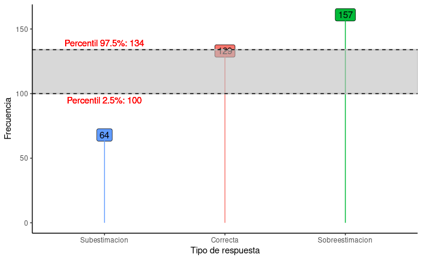

```r
ggplot(true_freq,
       aes(x = sesgo, y = n, color = sesgo)) +
  geom_label(aes(y = n + 4,label = n, fill = sesgo), size = 4, color = 'black') +
  geom_segment(aes(x=sesgo, xend=sesgo, y=0, yend=n)) +
  geom_rect(
    xmin = -Inf, xmax = Inf,
    aes(ymin = qbinom(0.025, 350, 1/3), ymax = qbinom(0.975, 350, 1/3)),
    alpha = 0.25,
    fill = 'grey',
    color = 'grey'
  ) +
  geom_hline(
    yintercept = qbinom(0.025, 350, 1/3),
    linetype = 'dashed'
  ) +
  geom_text(
    y = qbinom(0.025, 350, 1/3) - 5,
    x = 'sub',
    label = paste0('Percentil 2.5%: ',qbinom(0.025, 350, 1/3)),
    color = 'red'
  ) +
  geom_hline(
    yintercept = qbinom(0.975, 350, 1/3),
    linetype = 'dashed'
  ) +
  geom_text(
    y = qbinom(0.975, 350, 1/3) + 5,
    x = 'sub',
    label = paste0('Percentil 97.5%: ',qbinom(0.975, 350, 1/3)),
    color = 'red'
  ) +
  theme_classic() +
  ylab('Frecuencia') +
  theme(legend.position = 'none') +
  scale_x_discrete(
    'Tipo de respuesta',
    labels=c("ok" = "Correcta", "sobre" = "Sobreestimacion",
                              "sub" = "Subestimacion"),
    limits = c('sub', 'ok', 'sobre')
  )
ggsave('true_freq.png', width = 6)
```

Calculamos el intervalo del 95% de una distribucion binomial con probabilidad 1/3 equivalente a la distribucion nula para la categoria segun el N de la consistencia en la respuesta.

| Autopercepcion | Heteropercepcion | n | low_ci | mid_ci | high_ci | sesgo |
| --- | --- | --- | --- | --- | --- | --- |
| Consistente | Consistente | 228 | 62 | 76 | 90 | ok |
| Consistente | Inconsistente | 29 | 5 | 10 | 15 | ok |
| Inconsistente | Consistente | 68 | 15 | 23 | 30 | ok |
| Inconsistente | Inconsistente | 25 | 4 | 8 | 13 | ok |
| Consistente | Consistente | 228 | 62 | 76 | 90 | sobre |
| Consistente | Inconsistente | 29 | 5 | 10 | 15 | sobre |
| Inconsistente | Consistente | 68 | 15 | 23 | 30 | sobre |
| Inconsistente | Inconsistente | 25 | 4 | 8 | 13 | sobre |
| Consistente | Consistente | 228 | 62 | 76 | 90 | sub |
| Consistente | Inconsistente | 29 | 5 | 10 | 15 | sub |

[output cut: 2 more lines]

Graficamos cada frecuencia individual separando segun el nivel de consistencia en las respuestas. Agregamos una banda de compatibilidad con una distribucion nula segun lo calculado anteriormente

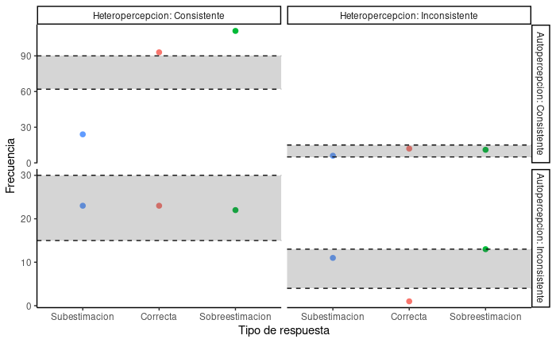

```r
ggplot(
  h3_dataset %>%
    mutate(error_otherperception = ifelse(error_otherperception, 'Inconsistente', 'Consistente'),
           error_selfperception = ifelse(error_selfperception, 'Inconsistente', 'Consistente'),
           ) %>%
    rename(Autopercepcion = error_selfperception,
           Heteropercepcion = error_otherperception) %>%
    count(sesgo, Heteropercepcion, Autopercepcion)
) +
  geom_point(aes(x = sesgo, y = n, color = sesgo), size = 2) +
  geom_hline(data = freq_binom_ci,
              aes(yintercept = low_ci), linetype = 'dashed') +
  geom_hline(data = freq_binom_ci,
              aes(yintercept = high_ci), linetype = 'dashed') +
  geom_rect(
    data = freq_binom_ci,
    xmin = -Inf, xmax = Inf,
    aes(ymin = low_ci, ymax = high_ci),
    alpha = 0.25
  ) +
  facet_grid(rows = vars(Autopercepcion), cols = vars(Heteropercepcion), scales = 'free', labeller = label_both) +
  theme_classic() +
  ylab('Frecuencia') +
  theme(legend.position = 'none') +
  scale_x_discrete(
    'Tipo de respuesta',
    labels=c("ok" = "Correcta", "sobre" = "Sobreestimacion",
                              "sub" = "Subestimacion"),
    limits = c('sub', 'ok', 'sobre')
  )
ggsave('freq_x_error.png')
```

Ahora tenemos que generar la distribucion nula de frecuencias, unicamente para los sujetos completamente consistentes.

```r
freq_nula <- replicate(
  10000,
  sample(c('ok', 'sobre','sub'), 228, replace = T) %>% as_tibble() %>% count(value) %>% pull(n)
  )
rownames(freq_nula) <- c('ok', 'sobre', 'sub')
freq_nula <- freq_nula %>% t() %>% as_tibble()
```

Calculamos de nuevo las verdaderas frecuencias pero utilizando unicamente los sujetos que fueron consistentes en todas sus respuestas.

Graficamos la distribucion nula comparando con la verdadera frecuencia

Primero para las respuestas correctas

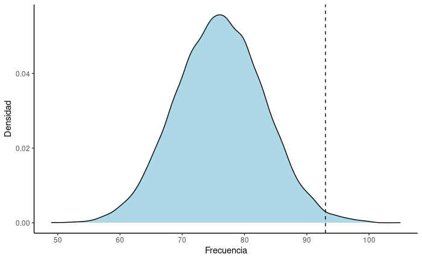

```r
PlotFreqNulaOk <- ggplot(
    freq_nula,
    aes(x = ok)
  ) +
  geom_density(fill = 'lightblue') +
  geom_vline(
    aes(xintercept = true_freq_consistente %>% filter(sesgo == 'ok') %>% pull(n)),
             linetype = 'dashed') +
  theme_classic() +
  xlab('Frecuencia') + ylab('Densidad')
PlotFreqNulaOk
```

```r
mean(freq_nula$ok >= true_freq_consistente %>% filter(sesgo == 'ok') %>% pull(n))
```

```
[1] 0.0106
```

Despues para las sobreestimaciones

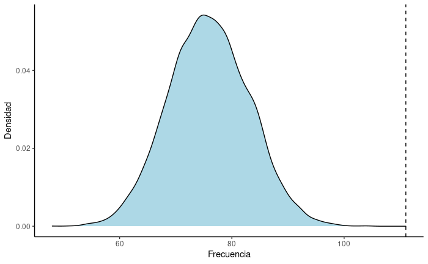

```r
PlotFreqNulaSobre <- ggplot(
    freq_nula,
    aes(x = sobre)
  ) +
  geom_density(fill = 'lightblue') +
  geom_vline(
    aes(xintercept = true_freq_consistente %>% filter(sesgo == 'sobre') %>% pull(n)),
             linetype = 'dashed') +
  theme_classic() +
  xlab('Frecuencia') + ylab('Densidad')
PlotFreqNulaSobre
```

```r
true_freq_consistente %>% filter(sesgo == 'sobre') %>% pull(n)
```

```
[1] 111
```

```r
quantile(freq_nula$sobre, c(0.025,0.975))
```

```
 2.5% 97.5%
   62    90
```

```r
mean(freq_nula$sobre >= true_freq_consistente %>% filter(sesgo == 'sobre') %>% pull(n))
```

```
[1] 0
```

Por ultimo para las subestimaciones

```r
PlotFreqNulaSub <- ggplot(
    freq_nula,
    aes(x = sobre)
  ) +
  geom_density(fill = 'lightblue') +
  geom_vline(
    aes(xintercept = true_freq_consistente %>% filter(sesgo == 'sub') %>% pull(n)),
             linetype = 'dashed') +
  theme_classic() +
  xlab('Frecuencia') + ylab('Densidad')
PlotFreqNulaSub
```

```r
h2_dataset <- final_dataset %>%
  drop_na(uso_screnshot)
```

Posteriormente calculamos si la categoria que asignaron segun su autopercepcion coincide con las horas reales de uso de instagram. Para eso utilizamos una lookup table.

```r
lookup_table <- data.frame(
  categoria = c('Más de 3 hs por día', '2-3 hs por día', '1-2 hs por día', '31-60 min por día', '10-30 min por día', 'Menos de 10 min por día'),
  uper_bound = c(Inf, 10800, 7200, 3600, 1800, 600),
  lower_bound = c(10800, 7200, 3600, 1860, 600, -Inf)
)


sesgo_estimacion_fun <- function(cat_value, num_value){
  acierto <- ifelse(
    between(num_value, lookup_table[lookup_table$categoria == cat_value, 3], lookup_table[lookup_table$categoria == cat_value, 2]), 'ok', F
    )
  if(acierto == F){
    if(
      num_value > lookup_table[lookup_table$categoria == cat_value, 2] #Si el valor esta por encima del umbral superior
    ){
      return('sub')
    }else{
      return('sobre')
    }
  }else{
    return(acierto)
  }
}
```

Utilizando los objetos creados anteriormente calculamos para cada sujeto si subestimo, sobreestimo o tuvo una estimacion correcta.

```r
h2_dataset <- h2_dataset %>%
  rowwise() %>%
  mutate(
  sesgo = sesgo_estimacion_fun(selfperception_cat, uso_screnshot)
  )
```

Para responder a la segunda hipotesis vemos los puntajes en la escala de FOMO para los distintos tipos de respuesta.

```r
violin_fomo_sesgo_plot_all <- h2_dataset %>%
  ggplot(aes(x = sesgo, y = fomo_puntaje, fill = sesgo)) +
  geom_violin(alpha = 0.75, trim = F) +
  stat_summary(fun.data = mean_se, fun.args = list('mult' = 2)) +
  stat_summary(fun.data = mean_se, fun.args = list('mult' = 2), geom = 'errorbar', width = 0.1) +
  ylab('FOMO') + xlab('Tipo de respuesta') +
  scale_fill_discrete('Tipo de respuesta', labels = c('Correcta', 'Sobreestimacion', 'Subestimacion')) +
  scale_x_discrete(
    labels=c("ok" = "Correcta", "sobre" = "Sobreestimacion",
                              "sub" = "Subestimacion"),
    limits = c('sub', 'ok', 'sobre')
  ) +
  theme_classic()
violin_fomo_sesgo_plot_all
```

Repetimos el mismo grafico pero esta vez excluimos aquellos sujetos cuya respuesta categorica no es consistente con su respuesta numerica.

```r
violin_fomo_sesgo_plot_self <- h2_dataset %>% filter(error_selfperception == FALSE) %>%
  ggplot(aes(x = sesgo, y = fomo_puntaje, fill = sesgo)) +
  geom_violin(alpha = 0.75, trim = F) +
  stat_summary(fun.data = mean_se, fun.args = list('mult' = 2)) +
  stat_summary(fun.data = mean_se, fun.args = list('mult' = 2), geom = 'errorbar', width = 0.1) +
  ylab('FOMO') + xlab('Tipo de respuesta') +
  scale_fill_discrete('Tipo de respuesta', labels = c('Correcta', 'Sobreestimacion', 'Subestimacion')) +
  scale_x_discrete(
    labels=c("ok" = "Correcta", "sobre" = "Sobreestimacion",
                              "sub" = "Subestimacion"),
    limits = c('sub', 'ok', 'sobre')
  ) +
  theme_classic()
violin_fomo_sesgo_plot_self
```

De nuevo repetimos el mismo grafico pero excluyendo a todos los sujetos, quienes respondieron incosistentemente a cualquiera de las dos categorias

```r
violin_fomo_sesgo_plot_none <- h2_dataset %>%
  filter(error_selfperception == FALSE & error_otherperception == FALSE) %>%
  ggplot(aes(x = sesgo, y = fomo_puntaje, fill = sesgo)) +
  geom_violin(alpha = 0.75, trim = F) +
  stat_summary(fun.data = mean_se, fun.args = list('mult' = 2)) +
  stat_summary(fun.data = mean_se, fun.args = list('mult' = 2), geom = 'errorbar', width = 0.1) +
  ylab('FOMO') + xlab('Tipo de respuesta') +
  scale_fill_discrete('Tipo de respuesta', labels = c('Correcta', 'Sobreestimacion', 'Subestimacion')) +
  scale_x_discrete(
    labels=c("ok" = "Correcta", "sobre" = "Sobreestimacion",
                              "sub" = "Subestimacion"),
    limits = c('sub', 'ok', 'sobre')
  ) +
  theme_classic()
violin_fomo_sesgo_plot_none
```

Combinamos todos los graficos en uno solo

```r
ggarrange(
  violin_fomo_sesgo_plot_all, violin_fomo_sesgo_plot_self, violin_fomo_sesgo_plot_none,
  labels = c('A', 'B', 'C'),
  ncol = 1, nrow = 3
)
ggsave('test.png',
       width = 15, height = 25, units = "cm")
```

Para hacer las comparaciones generamos un codigo que nos permita realizar permutaciones. La funcion toma simplemente un vector con dos categorias y un vector numerico con la variable de respuesta de interes.

```r
permutaciones_mean <- function(categoria, respuesta){
  shuffle_categoria <- sample(categoria, length(categoria))

  shuffle_df <- tibble(
    shuf_cat = shuffle_categoria,
    resp = respuesta
  )

  shuffle_df %>%
  group_by(shuf_cat) %>% summarise(x = mean(resp)) %>% summarise(x = diff(x)) %>% pull(x)
}
```

Siendo que vamos a usar esto varias veces lo empaquetamos en una funcion. La funcion toma como argumentos un dataframe, una string con el nombre de la columna con la categoria (binaria) y una string con el nombre de la variable de respuesta que nos interesa. Devuelve como resultado un vector de permutaciones.

```r
comparacion_permutaciones_fn <- function(dataset, nombre_categoria, nombre_respuesta){
  res_perm <- replicate(
  10000,
  permutaciones_mean(
    dataset[[nombre_categoria]],
    dataset[[nombre_respuesta]]
    )
  )
  return(res_perm)
}
```

Lo aplicamos primero comparando con la categoria de estimacion correcta para todos los sujetos usando 10 mil permutaciones.

```r
permutacion_ok <- comparacion_permutaciones_fn(h2_dataset %>% filter(sesgo != 'sobre'), 'sesgo', 'fomo_puntaje')
```

Graficamos el histograma de la distribucion de diferencias bajo la hipotesis nula.

```r
perm_plot_ok_all <- ggplot() +
  geom_histogram(
    aes(x = permutacion_ok),
    fill = 'white',
    color = 'black'
  ) +
  geom_vline(
    xintercept = mean(h2_dataset$fomo_puntaje[h2_dataset$sesgo == 'ok']) - mean(h2_dataset$fomo_puntaje[h2_dataset$sesgo == 'sub']),
    size = 1, linetype = 'dashed'
      ) +
  theme_classic() +
  xlab("Diferencia de medias") + ylab('Frecuencia')
perm_plot_ok_all
```

```r
mean(h2_dataset$fomo_puntaje[h2_dataset$sesgo == 'ok'])
mean(h2_dataset$fomo_puntaje[h2_dataset$sesgo == 'sub'])
mean(h2_dataset$fomo_puntaje[h2_dataset$sesgo == 'ok']) - mean(h2_dataset$fomo_puntaje[h2_dataset$sesgo == 'sub'])
quantile(permutacion_ok, c(0.025,0.975))
```

Replicamos el procedimiento anterior excluyendo aquellos sujetos con respuestas incosistentes en la autopercepcion.

```r
permutacion_ok_consistente <- comparacion_permutaciones_fn(
  h2_dataset %>% filter(sesgo != 'sobre' & error_selfperception == FALSE),
  'sesgo', 'fomo_puntaje'
  )

perm_plot_ok_self <- ggplot() +
  geom_histogram(
    aes(x = permutacion_ok_consistente),
    fill = 'white',
    color = 'black'
  ) +
  geom_vline(
    xintercept = mean(
      h2_dataset$fomo_puntaje[h2_dataset$sesgo == 'ok' & h2_dataset$error_selfperception == F]) - mean(h2_dataset$fomo_puntaje[h2_dataset$sesgo == 'sub' & h2_dataset$error_selfperception == F]),
    size = 1, linetype = 'dashed'
      ) +
  theme_classic() +
  xlab("Diferencia de medias") + ylab('Frecuencia')
```

```r
mean(h2_dataset$fomo_puntaje[h2_dataset$sesgo == 'ok' & h2_dataset$error_selfperception == F])
mean(h2_dataset$fomo_puntaje[h2_dataset$sesgo == 'sub' & h2_dataset$error_selfperception == F])
mean(
      h2_dataset$fomo_puntaje[h2_dataset$sesgo == 'ok' & h2_dataset$error_selfperception == F]) - mean(h2_dataset$fomo_puntaje[h2_dataset$sesgo == 'sub' & h2_dataset$error_selfperception == F])
quantile(permutacion_ok_consistente, c(0.025,0.975))
```

Por ultimo excluimos a aquellos que tuvieron una inconsistencia en la autoestimacion o la heteroestimacion

```r
permutacion_ok_all_consistente <- comparacion_permutaciones_fn(
  h2_dataset %>% filter(sesgo != 'sobre' & error_selfperception == FALSE & error_otherperception == FALSE),
  'sesgo', 'fomo_puntaje'
  )

perm_plot_ok_none <- ggplot() +
  geom_histogram(
    aes(x = permutacion_ok_all_consistente),
    fill = 'white',
    color = 'black'
  ) +
  geom_vline(
    xintercept = mean(
      h2_dataset %>% filter(sesgo == 'ok' & error_selfperception == FALSE & error_otherperception == FALSE) %>% pull(fomo_puntaje)
      ) - mean(
         h2_dataset %>% filter(sesgo == 'sub' & error_selfperception == FALSE & error_otherperception == FALSE) %>% pull(fomo_puntaje)
                                                                ),
    size = 1, linetype = 'dashed'
      ) +
  theme_classic() +
  xlab("Diferencia de medias") + ylab('Frecuencia')
perm_plot_ok_none
```

```r
#Mean sobreestimacion
mean(
      h2_dataset %>% filter(sesgo == 'ok' & error_selfperception == FALSE & error_otherperception == FALSE) %>% pull(fomo_puntaje)
      )
mean(
         h2_dataset %>% filter(sesgo == 'sub' & error_selfperception == FALSE & error_otherperception == FALSE) %>% pull(fomo_puntaje)
                                                                )
mean(
      h2_dataset %>% filter(sesgo == 'ok' & error_selfperception == FALSE & error_otherperception == FALSE) %>% pull(fomo_puntaje)
      ) - mean(
         h2_dataset %>% filter(sesgo == 'sub' & error_selfperception == FALSE & error_otherperception == FALSE) %>% pull(fomo_puntaje)
                                                                )

quantile(permutacion_ok_all_consistente, c(0.025,0.975))
```

Unimos todos los graficos en uno solo

```r
ggarrange(
  perm_plot_ok_all, perm_plot_ok_self, perm_plot_ok_none,
  labels = c('A', 'B', 'C'),
  ncol = 1, nrow = 3
)
ggsave('test.png',
       height = 13, width = 10, units = 'cm')
```

Ahora repetimos el procedimiento comparando los sujetos que hicieron una subestimacion con aquellos que hicieron una sobreestimacion

[figure not shown]

```r
cohens_d(fomo_puntaje ~ sesgo, data = h2_dataset %>% filter(sesgo != 'ok'), pooled_sd = F)
```

```
Cohen's d |       95% CI
------------------------
0.40      | [0.11, 0.69]

- Estimated using un-pooled SD.
```